# Time Series: A First Course with Bootstrap Starter

# Lesson 10-3: AR Identification

- We can determine AR model order by examining truncation of the PACF.

## Remark 10.3.1. AR Model Identification

- To identify an AR model, we must use the sample PACF rather than the true PACF.
- Take as null hypothesis that the process is an AR(p), such that
  $$H_0 : \kappa (k) = 0 \quad \mbox{for all} \; k > p.$$
- We can use the estimate $\widehat{\kappa} (k)$ as test statistic, for any $k > p$.
- We require an asymptotic distribution theory.

## Corollary 10.3.4.

- Suppose $\{ X_t \}$ is an AR($p$) process with mean $\mu$ and i.i.d. inputs of variance $\sigma^2$. Then
  $$\sqrt{n} (\widehat{\kappa} (k) - \kappa (k)) \Rightarrow \mathcal{N}
  (0, \sigma^2
  \underline{e}_k^{\prime} \Gamma_k^{-1} \underline{e}_k ),$$
  where $\underline{e}_k$ is the unit vector with one in last (index $k$) position.
- So the asymptotic variance is the bottom right entry of $\Gamma_k^{-1}$ times $\sigma^2$.

## Paradigm 10.3.6. AR Model Identification

- Suppose the true model is AR(p), and we test $H_0$ with $k > p$.
- Trick: the process is also an AR(k), where the last $k-p$ coefficients are zero!
- So we can apply Corollary 10.3.4, and it can be shown that because $k > p$ the limiting variance is $1$, i.e.,
  $$\sqrt{n} \, \widehat{\kappa} (k) \Rightarrow \mathcal{N} (0,1)$$
  under $H_0$.
- So we can do sequential testing using the sample PACF, with the same cautions about multiple testing.
- We also have an *Empirical Rule* for AR identification.

### **Empirical Rule**

- Let $\widehat{p}$ be the smallest positive integer such that
  $$| \widehat{\kappa} (\widehat{p}+k)| < c \sqrt{n^{-1} \log n}$$
  for all $k=1, \ldots, K_n$, where $c > 0$ is a fixed constant, and $K_n$ is a positive, non-decreasing integer-valued function of $n$ such that $K_n = o(\log n)$.
- Choose $c = 1.96$ and $K_n = 1 + [3 \sqrt{ \log n}]$

## Example 10.3.7. Identification of Urban World Population

- We now apply the Empirical Rule to the Urban World Population time series.
- We take second differences because of non-stationarity.
- The first $20$ sample autocorrelations and partial autocorrelations are plotted.

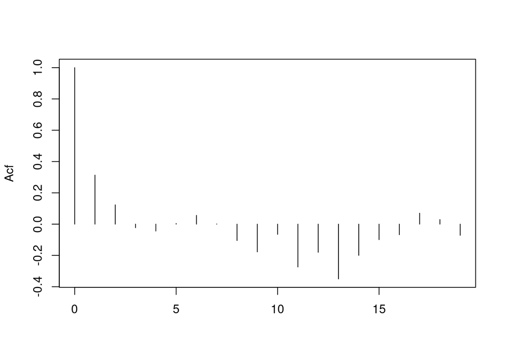

```r
urban <- read.table("urbanpop.dat")
urban <- ts(urban[67:1,], start = 1951)
urban.diff <- diff(diff(urban))
n <- length(urban.diff)
gamma.hat <- acf(urban.diff,lag=n-1,type="covariance",plot=FALSE)$acf[,,1]
kappa.hat <- pacf(urban.diff,lag=n-1,plot=FALSE)$acf[,,1]
plot(ts(gamma.hat[1:20]/gamma.hat[1],start=0),xlab="",ylab="Acf",type="h")
```

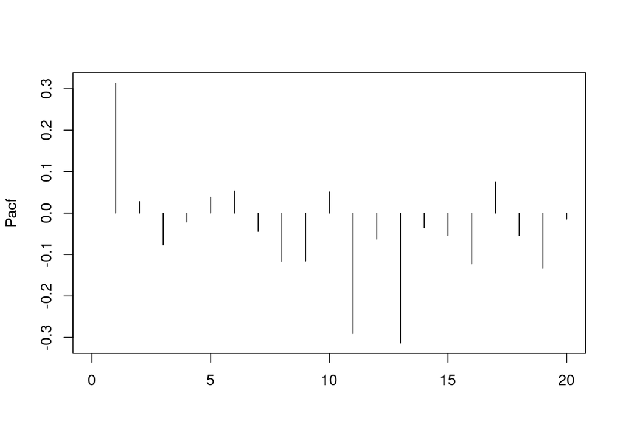

```r
plot(ts(c(NA,kappa.hat[1:20]),start=0),xlab="",ylab="Pacf",type="h")
```

```r
alpha <- .05
crit <- qnorm(1-alpha/2)
K.n <- 1 + floor(3*sqrt(log(n,base=10)))
print(kappa.hat[1:K.n])
```

```
## [1]  0.31328846  0.02786067 -0.07692737 -0.02165771  0.03832985
```

```r
kappa.test <- kappa.hat/sqrt(log(n,base=10)/n)
k <- 1
while(k < (n-K.n))
{
    if(max(abs(kappa.test[k:(k+K.n-1)])) < crit)
    {
        p.hat <- k-1
        k <- n-K.n
    } else { k <- k+1 }
}
```

- This results in AR identification of order 0.